# Python速習メモ

## 1. Pythonについて

### Pythonの特徴

- 動的型付けのインタプリタ型言語
- 標準でパッケージ管理ツール（pip）と仮想環境構築ツール（venv）が備わっている
- ライブラリが豊富
- インデントにより、ソースの構造を決める

### Anacondaとは

- Anaconda = Python + データ分析用ライブラリ + ツール類
- 標準のPythonとは、パッケージ管理ツールと仮想環境構築ツールが違う(Anacondaはcondaを使う)
- 主に、データ分析目的で使われる

### AnacondaとPythonどちらをインストールして使うか

- データ分析用途または、手軽に環境構築を行うならAnacondaを使い、それ以外は標準のPythonを使う

## 2. Pythonのインストール

[Pythonの公式サイト](https://www.python.org/downloads/) でインストーラをダウンロードして実行

※ Anacondaを使う場合は、[Anacondaの公式サイト](https://www.anaconda.com/products/individual) でインストーラをダウンロードして実行

## 3. Pythonの実行方法

コマンドプロンプトなどに、「python」と入力するとREPLが起動し、対話的にPythonの式や文が実行できる。 REPLを終了する場合は、「quit()」と入力する。

ファイルにPythonのソースを書いて実行する場合は（ここでは、test.pyに書いたとする）、「python test.py」のようにして行う。

## 4. 基礎的なデータ型と文法

### リテラル（よく使うもののみ）

- 整数（多倍長整数）
  - 例： -80, 100000000000000000000
- 浮動小数点
  - 例： 3.14, 6.332e2
- ブール値
  - 例: True, False
- 文字列（「"」か「'」で文字列を囲む）
  - 例："Hello", 'こんにちは'
- リスト（可変長配列）
  - 例：[4, 7, 10, 1]
- タプル（タプルの要素は不変）
  - 例： (3.14, "円周率")
- 辞書
  - 例： {"apple": "リンゴ", "banana": "バナナ"}

### 演算子

```python
# 代入
a = 3
a
```

```
3
```

```python
# 四則演算、複合代入演算子などはCやJavaと同じ使い方（インクリメントとデクリメントはない）
```

```python
2 + 4
```

```
6
```

```python
6 / 4 # 割り算による演算結果は常に浮動小数点数
```

```
1.5
```

```python
6 // 4 # 整数同士の割り算で、整数部を求めるならば、「//」を使う
```

```
1
```

```python
2 ** 64 # 「**」は、べき乗
```

```
18446744073709551616
```

```python
(True and True, False or True, not True) # and, or, notでブール演算
```

```
(True, True, False)
```

```python
# リストへのアクセス
z = [6, 3, 7]
z[2]
```

```
7
```

```python
z[2] = 0
z[2]
```

```
0
```

```python
# 部分リストを取得
z = [6, 3, 7]
z[0:2:1] # [始めのインデックス:終わりのインデックス（このインデックスの値は含まれない）:増分]
```

```
[6, 3]
```

```python
# 辞書へのアクセス
d = {}
d["田中"] = "太郎"
d["田中"]
```

```
'太郎'
```

```python
d["吉田"] = "次郎"
d
```

```
{'田中': '太郎', '吉田': '次郎'}
```

### 入出力

```python
inp = input("数字を入力してください： ") # input で入力を受け付ける
num = int(inp)
print(f"入力した数字を倍にすると {num * 2} になります。") # print で画面に出力
```

```
数字を入力してください： 4
入力した数字を倍にすると 8 になります。
```

### 制御文

```python
# if 文
x = 1
if x == 0:
    print("x は 0 です")
elif x == 1:
    print("x は 1 です")
else:
    print("x は 0 でも 1 でもないです")
```

```
x は 1 です
```

```python
# while 文
x = 1
while x < 1000:
    x *= 2
x
```

```
1024
```

```python
# for 文
for i in range(0, 10, 2):
    print(i)
```

```
0
2
4
6
8
```

```python
# for 文とwhile 文は 、breakでループを終了、continueで次のループに進められる
for i in range(10):
    if i == 3:
        continue
    elif i == 6:
        break
    print(i)
```

```
0
1
2
4
5
```

### 関数定義

```python
# def で関数定義。構文は以下の通り。
#
# def 関数名(カンマ区切りの引数リスト):
#     関数本体

def factorial(n):
    if n == 0:
        return 1
    else:
        return n * factorial(n - 1)
```

```python
factorial(5)
```

```
120
```

### 例外処理

```python
# try, except, finally で例外処理
try:
    print("40を0で割ると、")
    v = 40 / 0
except ZeroDivisionError as e:
    print("エラー発生！")
    print(e)
finally:
    print("終わり。")
```

```
40を0で割ると、
エラー発生！
division by zero
終わり。
```

## クラスの使い方

```python
# 構文
# class クラス名(親クラス): # 親クラスは省略でき、省略時は object が親クラスとなる。
#     # コンストラクタ
#     def __init__(self, カンマ区切りの引数リスト):
#         self.n = 1 # インスタンス変数
#
#    # インスタンスメソッド
#    def method(self, カンマ区切りの引数リスト):
#        メソッド本体

class A:
    def __init__(self, n):
        self.n = n

    def show(self):
        print(self.n)
```

```python
a = A(10)
a.show()
```

```
10
```

## 5. ライブラリ（numpyとmatplot）の使い方の例

```python
import numpy as np
import matplotlib.pyplot as plt
```

```python
x = np.arange(0, 2*np.pi, 0.001)
x
```

```
array([0.000e+00, 1.000e-03, 2.000e-03, ..., 6.281e+00, 6.282e+00,
       6.283e+00])
```

```python
y = np.sin(x)
y
```

```
array([ 0.        ,  0.001     ,  0.002     , ..., -0.00218531,
       -0.00118531, -0.00018531])
```

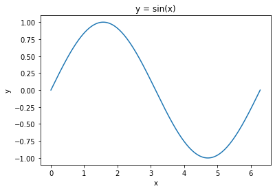

```python
plt.plot(x, y)
plt.title("y = sin(x)")
plt.xlabel("x")
plt.ylabel("y")
plt.savefig("sin.png")
plt.show()
```

## 参考サイト

- https://rinatz.github.io/python-book/
- https://www.python.ambitious-engineer.com/